# Restaurant Ratings Group Project - BDA January 2017

Matt,Rachana,Sharjeel,Ahmad

January 29, 2017

## 1. Overview of Dataset

We tested a number of different hypotheses with respect to restaurants in major US cities. We used Yelp’s Challenge Data - an open dataset with the following characteristics:

- 4.1M reviews and 947K tips by 1M users for 144K businesses
- 1.1M business attributes, e.g., hours, parking availability, ambience.
- Aggregated check-ins over time for each of the 125K businesses
- 200,000 pictures from the included businesses

## 2. Key Business Questions and Data Analysis Process

We sought primarily to answer the following questions:

1. What does the distribution of ratings and checkins look like for Yelp-listed restaurants in major US metropolitan areas?
2. To what extent can restaurant location (using population and median income of the zip code in which it is located as proxies) explain the variance in restaurant ratings and/or checkins?
3. Are there any other meaninful relationships or inferences we can draw between restaurant ratings and restaurant location, customer propensity to review the restaurant, or customer propensity to check in at the restaurant?

We ran ordered logistic regression and linear regresssions on this data in order to determine the predictive power of various restaurant features on the outcomes of interest, namely stars and checkins.

## 3. Data Import, Cleaning, and Analysis

```r
#uncompress data
library(foreign)

#import data and create dataframes
library(jsonlite)
YelpCheckins <- stream_in(file("C:/Users/Matthew/Documents/R/GroupProjectFinal/yelp_academic_dataset_checkin.json"),pagesize = 500)
```

```
## opening file input connection.
```

[output not shown]

[output cut: 199 more lines]

[output not shown]

```
## closing file input connection.
```

```r
YelpBusinesses <- stream_in(file("C:/Users/Matthew/Documents/R/GroupProjectFinal/yelp_academic_dataset_business.json"),pagesize = 500)
```

```
## opening file input connection.
```

[output not shown]

[output cut: 236 more lines]

[output not shown]

```
## closing file input connection.
```

```r
#make each individual checkin its own row
require(dplyr)
require(tidyr)
library(splitstackshape)
YelpCheckins_v2 <- YelpCheckins
YelpCheckins_v2 <- cSplit(YelpCheckins_v2, "time", sep = ",", direction = "long")

require(RCurl)
require(xlsx)
require(readxl)
urlfile <-'http://www.psc.isr.umich.edu/dis/census/Features/tract2zip/MedianZIP-3.xlsx'
destfile <- "census20062010.xlsx"
download.file(urlfile, destfile, mode="wb")
census <- read_excel(destfile, sheet = "Median")

# clean up data
names(census) <- c('postal_code','median_income','population')
census$median_income <- as.character(census$median_income)
census$median_income <- as.numeric(gsub(',','',census$median_income))
print(head(census,5))
```

```
## # A tibble: 5 × 3
##   postal_code median_income population
##         <dbl>         <dbl>      <dbl>
## 1        1001      56662.57      16445
## 2        1002      49853.42      28069
## 3        1003      28462.00       8491
## 4        1005      75423.00       4798
## 5        1007      79076.35      12962
```

```r
#strip out businesses that aren't restaurants, have fewer than 25 reviews, or are no longer active
require(plyr)
library(tidyverse)
library(stringr)

Restaurants_v1 <- subset(YelpBusinesses,is_open == 1)
Restaurants_v2 <- filter(Restaurants_v1 , grepl('Restaurants',categories))
Restaurants_v3 <- subset(Restaurants_v2,review_count > 25)

#merge checkins data with restaurants data, matching on business_id; remove restaurants located outside the US
Restaurants_v4 <- merge(x=Restaurants_v3, y=YelpCheckins_v2, by.x="business_id", by.y="business_id", all=TRUE)
Restaurants_v5 <- subset(Restaurants_v4,is_open == 1)

Restaurants_v5$business_id <- as.character(Restaurants_v5$business_id)

Restaurants_v5$checkin_count <- as.numeric(ave(Restaurants_v5$business_id, Restaurants_v5$business_id, FUN = length))

Restaurants_v6 <- subset(Restaurants_v5,!duplicated(business_id),-c(17))
Restaurants_v7 <- subset(Restaurants_v6,nchar(postal_code)==5)

Restaurants_v8 <- merge(x=Restaurants_v7,y=census,by.x="postal_code",by.y = "postal_code",scale(population))

ScaledMedianIncome <- scale(Restaurants_v8$median_income)
ScaledPopulation <- scale(Restaurants_v8$population)
Restaurants_v8$median_income <- ScaledMedianIncome
Restaurants_v8$population <- ScaledPopulation
Restaurants_final <- Restaurants_v8

#Divides restaurant dataset into training set and test set
RestaurantsTestSet <- Restaurants_final[sample(nrow(Restaurants_final), 11431/2), ]
Restaurants_New <- merge(x=Restaurants_final,y=RestaurantsTestSet, by.x = "business_id", by.y = "business_id",all=TRUE)
RestaurantsTrainingSet <- subset(Restaurants_New,attributes.y == "NA")

#Checks for equivalence of training set and test set
mean(RestaurantsTestSet$stars,na.rm=TRUE)
```

```
## [1] 3.621522
```

```r
mean(RestaurantsTrainingSet$stars.x,na.rm=TRUE)
```

```
## [1] 3.6236
```

```r
sd(RestaurantsTestSet$stars,na.rm=TRUE)
```

```
## [1] 0.6209718
```

```r
sd(RestaurantsTrainingSet$stars.x,na.rm=TRUE)
```

```
## [1] 0.6163316
```

```r
mean(RestaurantsTestSet$stars,na.rm=TRUE) - mean(RestaurantsTrainingSet$stars.x,na.rm=TRUE)
```

```
## [1] -0.00207811
```

```r
sd(RestaurantsTestSet$stars,na.rm=TRUE) - sd(RestaurantsTrainingSet$stars.x,na.rm=TRUE)
```

```
## [1] 0.004640246
```

```r
mean(RestaurantsTestSet$checkin_count,na.rm=TRUE)
```

```
## [1] 71.68224
```

```r
mean(RestaurantsTrainingSet$checkin_count.x,na.rm=TRUE)
```

```
## [1] 72.0007
```

```r
sd(RestaurantsTestSet$checkin_count,na.rm=TRUE)
```

```
## [1] 30.93848
```

```r
sd(RestaurantsTrainingSet$checkin_count.x,na.rm=TRUE)
```

```
## [1] 30.84472
```

```r
mean(RestaurantsTestSet$checkin_count,na.rm=TRUE) - mean(RestaurantsTrainingSet$checkin_count.x,na.rm=TRUE)
```

```
## [1] -0.3184601
```

```r
sd(RestaurantsTestSet$checkin_count,na.rm=TRUE) - sd(RestaurantsTrainingSet$checkin_count.x,na.rm=TRUE)
```

```
## [1] 0.09376093
```

```r
mean(RestaurantsTestSet$review_count,na.rm=TRUE)
```

```
## [1] 149.1207
```

```r
mean(RestaurantsTrainingSet$review_count.x,na.rm=TRUE)
```

```
## [1] 146.3754
```

```r
sd(RestaurantsTestSet$review_count,na.rm=TRUE)
```

```
## [1] 257.6816
```

```r
sd(RestaurantsTrainingSet$review_count.x,na.rm=TRUE)
```

```
## [1] 227.1995
```

```r
mean(RestaurantsTestSet$review_count,na.rm=TRUE) - mean(RestaurantsTrainingSet$review_count.x,na.rm=TRUE)
```

```
## [1] 2.745298
```

```r
sd(RestaurantsTestSet$review_count,na.rm=TRUE) - sd(RestaurantsTrainingSet$review_count.x,na.rm=TRUE)
```

```
## [1] 30.48209
```

```r
sapply(RestaurantsTestSet,mean, na.rm=TRUE)
```

[output not shown]

```
##   postal_code   business_id          name  neighborhood       address
##            NA            NA            NA            NA            NA
##          city         state      latitude     longitude         stars
##            NA            NA  3.647610e+01 -1.011885e+02  3.621522e+00
##  review_count       is_open    attributes    categories         hours
##  1.491207e+02  1.000000e+00            NA            NA            NA
##        type.x        type.y checkin_count median_income    population
##            NA            NA  7.168224e+01 -1.965074e-03 -2.510127e-03
```

```r
sapply(RestaurantsTrainingSet,mean,na.rm=TRUE)
```

[output not shown]

[output cut: 13 more lines]

[output not shown]

```
##     business_id   postal_code.x          name.x  neighborhood.x
##              NA              NA              NA              NA
##       address.x          city.x         state.x      latitude.x
##              NA              NA              NA    3.643328e+01
##     longitude.x         stars.x  review_count.x       is_open.x
##   -1.015357e+02    3.623600e+00    1.463754e+02    1.000000e+00
##    attributes.x    categories.x         hours.x        type.x.x
##              NA              NA              NA              NA
##        type.y.x checkin_count.x median_income.x    population.x
##              NA    7.200070e+01    1.964731e-03    2.509688e-03
##   postal_code.y          name.y  neighborhood.y       address.y
##              NA              NA              NA              NA
##          city.y         state.y      latitude.y     longitude.y
##              NA              NA             NaN             NaN
##         stars.y  review_count.y       is_open.y    attributes.y
##             NaN             NaN             NaN              NA
##    categories.y         hours.y        type.x.y        type.y.y
##              NA              NA              NA              NA
## checkin_count.y median_income.y    population.y
##             NaN             NaN             NaN
```

```r
Restaurants_v8 <- merge(x=Restaurants_v7,y=census,by.x="postal_code",by.y = "postal_code",scale(population))

ScaledMedianIncome <- scale(Restaurants_v8$median_income)
ScaledPopulation <- scale(Restaurants_v8$population)
Restaurants_v8$median_income <- ScaledMedianIncome
Restaurants_v8$population <- ScaledPopulation
Restaurants_final <- Restaurants_v8


#Divides restaurant dataset into training set and test set
RestaurantsTestSet <- Restaurants_final[sample(nrow(Restaurants_final), 11431/2), ]
Restaurants_New <- merge(x=Restaurants_final,y=RestaurantsTestSet, by.x = "business_id", by.y = "business_id",all=TRUE)
RestaurantsTrainingSet <- subset(Restaurants_New,attributes.y == "NA")

#Checks for equivalence of training set and test set
mean(RestaurantsTestSet$stars,na.rm=TRUE)
```

```
## [1] 3.629396
```

```r
mean(RestaurantsTrainingSet$stars.x,na.rm=TRUE)
```

```
## [1] 3.615728
```

```r
sd(RestaurantsTestSet$stars,na.rm=TRUE)
```

```
## [1] 0.6088344
```

```r
sd(RestaurantsTrainingSet$stars.x,na.rm=TRUE)
```

```
## [1] 0.6282495
```

```r
mean(RestaurantsTestSet$stars,na.rm=TRUE) - mean(RestaurantsTrainingSet$stars.x,na.rm=TRUE)
```

```
## [1] 0.01366854
```

```r
sd(RestaurantsTestSet$stars,na.rm=TRUE) - sd(RestaurantsTrainingSet$stars.x,na.rm=TRUE)
```

```
## [1] -0.01941517
```

```r
mean(RestaurantsTestSet$checkin_count,na.rm=TRUE)
```

```
## [1] 71.58128
```

```r
mean(RestaurantsTrainingSet$checkin_count.x,na.rm=TRUE)
```

```
## [1] 72.10164
```

```r
sd(RestaurantsTestSet$checkin_count,na.rm=TRUE)
```

```
## [1] 31.05963
```

```r
sd(RestaurantsTrainingSet$checkin_count.x,na.rm=TRUE)
```

```
## [1] 30.72136
```

```r
mean(RestaurantsTestSet$checkin_count,na.rm=TRUE) - mean(RestaurantsTrainingSet$checkin_count.x,na.rm=TRUE)
```

```
## [1] -0.5203672
```

```r
sd(RestaurantsTestSet$checkin_count,na.rm=TRUE) - sd(RestaurantsTrainingSet$checkin_count.x,na.rm=TRUE)
```

```
## [1] 0.3382641
```

```r
mean(RestaurantsTestSet$review_count,na.rm=TRUE)
```

```
## [1] 146.2483
```

```r
mean(RestaurantsTrainingSet$review_count.x,na.rm=TRUE)
```

```
## [1] 149.2474
```

```r
sd(RestaurantsTestSet$review_count,na.rm=TRUE)
```

```
## [1] 249.672
```

```r
sd(RestaurantsTrainingSet$review_count.x,na.rm=TRUE)
```

```
## [1] 235.9701
```

```r
mean(RestaurantsTestSet$review_count,na.rm=TRUE) - mean(RestaurantsTrainingSet$review_count.x,na.rm=TRUE)
```

```
## [1] -2.999082
```

```r
sd(RestaurantsTestSet$review_count,na.rm=TRUE) - sd(RestaurantsTrainingSet$review_count.x,na.rm=TRUE)
```

```
## [1] 13.70188
```

```r
sapply(RestaurantsTestSet,mean, na.rm=TRUE)
```

[output not shown]

```
##   postal_code   business_id          name  neighborhood       address
##            NA            NA            NA            NA            NA
##          city         state      latitude     longitude         stars
##            NA            NA  3.650779e+01 -1.011359e+02  3.629396e+00
##  review_count       is_open    attributes    categories         hours
##  1.462483e+02  1.000000e+00            NA            NA            NA
##        type.x        type.y checkin_count median_income    population
##            NA            NA  7.158128e+01  1.401877e-02 -3.197292e-03
```

```r
sapply(RestaurantsTrainingSet,mean,na.rm=TRUE)
```

[output not shown]

[output cut: 13 more lines]

[output not shown]

```
##     business_id   postal_code.x          name.x  neighborhood.x
##              NA              NA              NA              NA
##       address.x          city.x         state.x      latitude.x
##              NA              NA              NA    3.640160e+01
##     longitude.x         stars.x  review_count.x       is_open.x
##   -1.015882e+02    3.615728e+00    1.492474e+02    1.000000e+00
##    attributes.x    categories.x         hours.x        type.x.x
##              NA              NA              NA              NA
##        type.y.x checkin_count.x median_income.x    population.x
##              NA    7.210164e+01   -1.401632e-02    3.196732e-03
##   postal_code.y          name.y  neighborhood.y       address.y
##              NA              NA              NA              NA
##          city.y         state.y      latitude.y     longitude.y
##              NA              NA             NaN             NaN
##         stars.y  review_count.y       is_open.y    attributes.y
##             NaN             NaN             NaN              NA
##    categories.y         hours.y        type.x.y        type.y.y
##              NA              NA              NA              NA
## checkin_count.y median_income.y    population.y
##             NaN             NaN             NaN
```

```r
#require packages for logistic regression
require(foreign)
require(nnet)
```

```r
require(ggplot2)
require(reshape2)
require(MASS)
require(ResourceSelection)
```

```
## ResourceSelection 0.3-0   2016-11-04
```

```r
#run ordered logistic regressions to assess the predictive power of checkins, number of ratings, median income, and population on restaurant ratings
Stars_ReviewCount_LogitModel <- polr(as.factor(stars.x) ~ review_count.x, data=RestaurantsTrainingSet, Hess = TRUE)
Stars_Checkin_LogitModel <- polr(as.factor(stars.x) ~ checkin_count.x, data=RestaurantsTrainingSet, Hess = TRUE)
Stars_MedianIncome_LogitModel <- polr(as.factor(stars.x) ~ median_income.x, data=RestaurantsTrainingSet, Hess = TRUE)
Stars_Population_LogitModel <- polr(as.factor(stars.x) ~ population.x, data=RestaurantsTrainingSet, Hess = TRUE)

#run linear regressions to assess the predictive power of checkins, number of ratings, population, and median income on restaurant ratings
Stars_ReviewCount_LinearModel <- glm((stars.x) ~ review_count.x, data=RestaurantsTrainingSet)
Stars_Checkin_LinearModel <- glm((stars.x) ~ checkin_count.x, data=RestaurantsTrainingSet)
Stars_Income_LinearModel <- glm((stars.x) ~ median_income.x, data=RestaurantsTrainingSet)
Stars_Population_LinearModel <- glm((stars.x) ~ population.x, data=RestaurantsTrainingSet)

#run linear regressions to assess the predictive power of stars, number of ratings, population, and income on restaurant checkins
Checkins_ReviewCount_LinearModel <- glm((checkin_count.x) ~ review_count.x, data=RestaurantsTrainingSet)
Checkins_Stars_LinearModel <- glm((checkin_count.x) ~ stars.x, data=RestaurantsTrainingSet)
Checkins_Income_LinearModel <- glm((checkin_count.x) ~ median_income.x, data=RestaurantsTrainingSet)
Checkins_Population_LinearModel <- glm((checkin_count.x) ~ population.x, data=RestaurantsTrainingSet)

#Produce summaries
summary(Stars_ReviewCount_LogitModel)
```

```
## Call:
## polr(formula = as.factor(stars.x) ~ review_count.x, data = RestaurantsTrainingSet,
##     Hess = TRUE)
##
## Coefficients:
##                   Value Std. Error t value
## review_count.x 0.001661  0.0001215   13.67
##
## Intercepts:
##       Value    Std. Error t value
## 1|1.5  -7.7582   0.7018   -11.0547
## 1.5|2  -5.0465   0.1835   -27.5051
## 2|2.5  -3.4201   0.0842   -40.6202
## 2.5|3  -2.0526   0.0475   -43.1728
## 3|3.5  -0.8572   0.0343   -24.9695
## 3.5|4   0.4056   0.0324    12.5234
## 4|4.5   2.1285   0.0450    47.2916
## 4.5|5   5.0761   0.1463    34.7068
##
## Residual Deviance: 18245.69
## AIC: 18263.69
```

```r
summary(Stars_Checkin_LogitModel)
```

```
## Call:
## polr(formula = as.factor(stars.x) ~ checkin_count.x, data = RestaurantsTrainingSet,
##     Hess = TRUE)
##
## Coefficients:
##                     Value Std. Error t value
## checkin_count.x -0.001057  0.0007821  -1.351
##
## Intercepts:
##       Value    Std. Error t value
## 1|1.5  -8.0332   0.7081   -11.3442
## 1.5|2  -5.3214   0.1917   -27.7573
## 2|2.5  -3.6978   0.1008   -36.6748
## 2.5|3  -2.3377   0.0731   -31.9689
## 3|3.5  -1.1587   0.0651   -17.7934
## 3.5|4   0.0715   0.0634     1.1275
## 4|4.5   1.7443   0.0686    25.4115
## 4.5|5   4.6342   0.1514    30.6023
##
## Residual Deviance: 18465.77
## AIC: 18483.77
```

```r
summary(Stars_MedianIncome_LogitModel)
```

```
## Call:
## polr(formula = as.factor(stars.x) ~ median_income.x, data = RestaurantsTrainingSet,
##     Hess = TRUE)
##
## Coefficients:
##                    Value Std. Error t value
## median_income.x -0.04757     0.0237  -2.007
##
## Intercepts:
##       Value    Std. Error t value
## 1|1.5  -7.9578   0.7067   -11.2610
## 1.5|2  -5.2449   0.1830   -28.6537
## 2|2.5  -3.6211   0.0830   -43.6200
## 2.5|3  -2.2608   0.0452   -49.9877
## 3|3.5  -1.0817   0.0304   -35.5579
## 3.5|4   0.1491   0.0265     5.6185
## 4|4.5   1.8224   0.0382    47.6911
## 4.5|5   4.7119   0.1407    33.4984
##
## Residual Deviance: 18463.56
## AIC: 18481.56
```

```r
summary(Stars_Population_LogitModel)
```

```
## Call:
## polr(formula = as.factor(stars.x) ~ population.x, data = RestaurantsTrainingSet,
##     Hess = TRUE)
##
## Coefficients:
##                Value Std. Error t value
## population.x 0.01526    0.02361  0.6462
##
## Intercepts:
##       Value    Std. Error t value
## 1|1.5  -7.9573   0.7068   -11.2587
## 1.5|2  -5.2447   0.1831   -28.6513
## 2|2.5  -3.6207   0.0830   -43.6170
## 2.5|3  -2.2603   0.0452   -49.9817
## 3|3.5  -1.0811   0.0304   -35.5457
## 3.5|4   0.1493   0.0265     5.6278
## 4|4.5   1.8215   0.0382    47.6787
## 4.5|5   4.7104   0.1407    33.4882
##
## Residual Deviance: 18467.18
## AIC: 18485.18
```

```r
summary(Stars_ReviewCount_LinearModel)
```

```
##
## Call:
## glm(formula = (stars.x) ~ review_count.x, data = RestaurantsTrainingSet)
##
## Deviance Residuals:
##      Min        1Q    Median        3Q       Max
## -2.55812  -0.55566  -0.06008   0.42174   1.44483
##
## Coefficients:
##                 Estimate Std. Error t value Pr(>|t|)
## (Intercept)    3.542e+00  9.665e-03  366.54   <2e-16 ***
## review_count.x 4.913e-04  3.462e-05   14.19   <2e-16 ***
## ---
## Signif. codes:  0 '***' 0.001 '**' 0.01 '*' 0.05 '.' 0.1 ' ' 1
##
## (Dispersion parameter for gaussian family taken to be 0.3813214)
##
##     Null deviance: 2255.7  on 5715  degrees of freedom
## Residual deviance: 2178.9  on 5714  degrees of freedom
## AIC: 10714
##
## Number of Fisher Scoring iterations: 2
```

```r
summary(Stars_Checkin_LinearModel)
```

```
##
## Call:
## glm(formula = (stars.x) ~ checkin_count.x, data = RestaurantsTrainingSet)
##
## Deviance Residuals:
##     Min       1Q   Median       3Q      Max
## -2.6204  -0.6061  -0.1109   0.3862   1.3940
##
## Coefficients:
##                   Estimate Std. Error t value Pr(>|t|)
## (Intercept)      3.6255159  0.0212020 170.999   <2e-16 ***
## checkin_count.x -0.0001358  0.0002705  -0.502    0.616
## ---
## Signif. codes:  0 '***' 0.001 '**' 0.01 '*' 0.05 '.' 0.1 ' ' 1
##
## (Dispersion parameter for gaussian family taken to be 0.3947492)
##
##     Null deviance: 2255.7  on 5715  degrees of freedom
## Residual deviance: 2255.6  on 5714  degrees of freedom
## AIC: 10912
##
## Number of Fisher Scoring iterations: 2
```

```r
summary(Stars_Income_LinearModel)
```

```
##
## Call:
## glm(formula = (stars.x) ~ median_income.x, data = RestaurantsTrainingSet)
##
## Deviance Residuals:
##      Min        1Q    Median        3Q       Max
## -2.63177  -0.58771  -0.09972   0.38805   1.41374
##
## Coefficients:
##                  Estimate Std. Error t value Pr(>|t|)
## (Intercept)      3.615530   0.008309 435.122   <2e-16 ***
## median_income.x -0.014077   0.008404  -1.675    0.094 .
## ---
## Signif. codes:  0 '***' 0.001 '**' 0.01 '*' 0.05 '.' 0.1 ' ' 1
##
## (Dispersion parameter for gaussian family taken to be 0.3945728)
##
##     Null deviance: 2255.7  on 5715  degrees of freedom
## Residual deviance: 2254.6  on 5714  degrees of freedom
## AIC: 10910
##
## Number of Fisher Scoring iterations: 2
```

```r
summary(Stars_Population_LinearModel)
```

```
##
## Call:
## glm(formula = (stars.x) ~ population.x, data = RestaurantsTrainingSet)
##
## Deviance Residuals:
##     Min       1Q   Median       3Q      Max
## -2.6155  -0.6087  -0.1106   0.3861   1.3913
##
## Coefficients:
##              Estimate Std. Error t value Pr(>|t|)
## (Intercept)  3.615715   0.008310 435.088   <2e-16 ***
## population.x 0.004012   0.008269   0.485    0.628
## ---
## Signif. codes:  0 '***' 0.001 '**' 0.01 '*' 0.05 '.' 0.1 ' ' 1
##
## (Dispersion parameter for gaussian family taken to be 0.3947503)
##
##     Null deviance: 2255.7  on 5715  degrees of freedom
## Residual deviance: 2255.6  on 5714  degrees of freedom
## AIC: 10912
##
## Number of Fisher Scoring iterations: 2
```

```r
summary(Checkins_ReviewCount_LinearModel)
```

```
##
## Call:
## glm(formula = (checkin_count.x) ~ review_count.x, data = RestaurantsTrainingSet)
##
## Deviance Residuals:
##      Min        1Q    Median        3Q       Max
## -264.736   -18.133     0.405    16.264    95.324
##
## Coefficients:
##                 Estimate Std. Error t value Pr(>|t|)
## (Intercept)    62.538390   0.418583  149.41   <2e-16 ***
## review_count.x  0.064077   0.001499   42.74   <2e-16 ***
## ---
## Signif. codes:  0 '***' 0.001 '**' 0.01 '*' 0.05 '.' 0.1 ' ' 1
##
## (Dispersion parameter for gaussian family taken to be 715.3087)
##
##     Null deviance: 5393830  on 5715  degrees of freedom
## Residual deviance: 4087274  on 5714  degrees of freedom
## AIC: 53795
##
## Number of Fisher Scoring iterations: 2
```

```r
summary(Checkins_Stars_LinearModel )
```

```
##
## Call:
## glm(formula = (checkin_count.x) ~ stars.x, data = RestaurantsTrainingSet)
##
## Deviance Residuals:
##     Min       1Q   Median       3Q      Max
## -71.464  -22.855   -0.464   19.861   96.185
##
## Coefficients:
##             Estimate Std. Error t value Pr(>|t|)
## (Intercept)  73.2754     2.3740  30.866   <2e-16 ***
## stars.x      -0.3246     0.6469  -0.502    0.616
## ---
## Signif. codes:  0 '***' 0.001 '**' 0.01 '*' 0.05 '.' 0.1 ' ' 1
##
## (Dispersion parameter for gaussian family taken to be 943.9258)
##
##     Null deviance: 5393830  on 5715  degrees of freedom
## Residual deviance: 5393592  on 5714  degrees of freedom
## AIC: 55380
##
## Number of Fisher Scoring iterations: 2
```

```r
summary(Checkins_Income_LinearModel)
```

```
##
## Call:
## glm(formula = (checkin_count.x) ~ median_income.x, data = RestaurantsTrainingSet)
##
## Deviance Residuals:
##     Min       1Q   Median       3Q      Max
## -75.399  -22.685   -0.382   19.769   96.600
##
## Coefficients:
##                 Estimate Std. Error t value Pr(>|t|)
## (Intercept)      72.0650     0.4050 177.948  < 2e-16 ***
## median_income.x  -2.6158     0.4096  -6.387 1.83e-10 ***
## ---
## Signif. codes:  0 '***' 0.001 '**' 0.01 '*' 0.05 '.' 0.1 ' ' 1
##
## (Dispersion parameter for gaussian family taken to be 937.2769)
##
##     Null deviance: 5393830  on 5715  degrees of freedom
## Residual deviance: 5355600  on 5714  degrees of freedom
## AIC: 55340
##
## Number of Fisher Scoring iterations: 2
```

```r
summary(Checkins_Population_LinearModel)
```

```
##
## Call:
## glm(formula = (checkin_count.x) ~ population.x, data = RestaurantsTrainingSet)
##
## Deviance Residuals:
##     Min       1Q   Median       3Q      Max
## -72.661  -22.730   -0.532   19.917   97.111
##
## Coefficients:
##              Estimate Std. Error t value Pr(>|t|)
## (Intercept)   72.1046     0.4062 177.509   <2e-16 ***
## population.x  -0.9099     0.4042  -2.251   0.0244 *
## ---
## Signif. codes:  0 '***' 0.001 '**' 0.01 '*' 0.05 '.' 0.1 ' ' 1
##
## (Dispersion parameter for gaussian family taken to be 943.1308)
##
##     Null deviance: 5393830  on 5715  degrees of freedom
## Residual deviance: 5389049  on 5714  degrees of freedom
## AIC: 55375
##
## Number of Fisher Scoring iterations: 2
```

```r
#require packages for logistic regression
require(foreign)
require(nnet)
require(ggplot2)
require(reshape2)
require(MASS)
require(ResourceSelection)

#run ordered logistic regressions to assess the predictive power of checkins, number of ratings, median income, and population on restaurant ratings
Stars_ReviewCount_LogitModel <- polr(as.factor(stars.x) ~ review_count.x, data=RestaurantsTrainingSet, Hess = TRUE)
Stars_Checkin_LogitModel <- polr(as.factor(stars.x) ~ checkin_count.x, data=RestaurantsTrainingSet, Hess = TRUE)
Stars_MedianIncome_LogitModel <- polr(as.factor(stars.x) ~ median_income.x, data=RestaurantsTrainingSet, Hess = TRUE)
Stars_Population_LogitModel <- polr(as.factor(stars.x) ~ population.x, data=RestaurantsTrainingSet, Hess = TRUE)

#run linear regressions to assess the predictive power of checkins, number of ratings, population, and median income on restaurant ratings
Stars_ReviewCount_LinearModel <- glm((stars.x) ~ review_count.x, data=RestaurantsTrainingSet)
Stars_Checkin_LinearModel <- glm((stars.x) ~ checkin_count.x, data=RestaurantsTrainingSet)
Stars_Income_LinearModel <- glm((stars.x) ~ median_income.x, data=RestaurantsTrainingSet)
Stars_Population_LinearModel <- glm((stars.x) ~ population.x, data=RestaurantsTrainingSet)

#run linear regressions to assess the predictive power of stars, number of ratings, population, and income on restaurant checkins
Checkins_ReviewCount_LinearModel <- glm((checkin_count.x) ~ review_count.x, data=RestaurantsTrainingSet)
Checkins_Stars_LinearModel <- glm((checkin_count.x) ~ stars.x, data=RestaurantsTrainingSet)
Checkins_Income_LinearModel <- glm((checkin_count.x) ~ median_income.x, data=RestaurantsTrainingSet)
Checkins_Population_LinearModel <- glm((checkin_count.x) ~ population.x, data=RestaurantsTrainingSet)

#Produce summaries
summary(Stars_ReviewCount_LogitModel)
```

```
## Call:
## polr(formula = as.factor(stars.x) ~ review_count.x, data = RestaurantsTrainingSet,
##     Hess = TRUE)
##
## Coefficients:
##                   Value Std. Error t value
## review_count.x 0.001661  0.0001215   13.67
##
## Intercepts:
##       Value    Std. Error t value
## 1|1.5  -7.7582   0.7018   -11.0547
## 1.5|2  -5.0465   0.1835   -27.5051
## 2|2.5  -3.4201   0.0842   -40.6202
## 2.5|3  -2.0526   0.0475   -43.1728
## 3|3.5  -0.8572   0.0343   -24.9695
## 3.5|4   0.4056   0.0324    12.5234
## 4|4.5   2.1285   0.0450    47.2916
## 4.5|5   5.0761   0.1463    34.7068
##
## Residual Deviance: 18245.69
## AIC: 18263.69
```

```r
summary(Stars_Checkin_LogitModel)
```

```
## Call:
## polr(formula = as.factor(stars.x) ~ checkin_count.x, data = RestaurantsTrainingSet,
##     Hess = TRUE)
##
## Coefficients:
##                     Value Std. Error t value
## checkin_count.x -0.001057  0.0007821  -1.351
##
## Intercepts:
##       Value    Std. Error t value
## 1|1.5  -8.0332   0.7081   -11.3442
## 1.5|2  -5.3214   0.1917   -27.7573
## 2|2.5  -3.6978   0.1008   -36.6748
## 2.5|3  -2.3377   0.0731   -31.9689
## 3|3.5  -1.1587   0.0651   -17.7934
## 3.5|4   0.0715   0.0634     1.1275
## 4|4.5   1.7443   0.0686    25.4115
## 4.5|5   4.6342   0.1514    30.6023
##
## Residual Deviance: 18465.77
## AIC: 18483.77
```

```r
summary(Stars_MedianIncome_LogitModel)
```

```
## Call:
## polr(formula = as.factor(stars.x) ~ median_income.x, data = RestaurantsTrainingSet,
##     Hess = TRUE)
##
## Coefficients:
##                    Value Std. Error t value
## median_income.x -0.04757     0.0237  -2.007
##
## Intercepts:
##       Value    Std. Error t value
## 1|1.5  -7.9578   0.7067   -11.2610
## 1.5|2  -5.2449   0.1830   -28.6537
## 2|2.5  -3.6211   0.0830   -43.6200
## 2.5|3  -2.2608   0.0452   -49.9877
## 3|3.5  -1.0817   0.0304   -35.5579
## 3.5|4   0.1491   0.0265     5.6185
## 4|4.5   1.8224   0.0382    47.6911
## 4.5|5   4.7119   0.1407    33.4984
##
## Residual Deviance: 18463.56
## AIC: 18481.56
```

```r
summary(Stars_Population_LogitModel)
```

```
## Call:
## polr(formula = as.factor(stars.x) ~ population.x, data = RestaurantsTrainingSet,
##     Hess = TRUE)
##
## Coefficients:
##                Value Std. Error t value
## population.x 0.01526    0.02361  0.6462
##
## Intercepts:
##       Value    Std. Error t value
## 1|1.5  -7.9573   0.7068   -11.2587
## 1.5|2  -5.2447   0.1831   -28.6513
## 2|2.5  -3.6207   0.0830   -43.6170
## 2.5|3  -2.2603   0.0452   -49.9817
## 3|3.5  -1.0811   0.0304   -35.5457
## 3.5|4   0.1493   0.0265     5.6278
## 4|4.5   1.8215   0.0382    47.6787
## 4.5|5   4.7104   0.1407    33.4882
##
## Residual Deviance: 18467.18
## AIC: 18485.18
```

```r
summary(Stars_ReviewCount_LinearModel)
```

```
##
## Call:
## glm(formula = (stars.x) ~ review_count.x, data = RestaurantsTrainingSet)
##
## Deviance Residuals:
##      Min        1Q    Median        3Q       Max
## -2.55812  -0.55566  -0.06008   0.42174   1.44483
##
## Coefficients:
##                 Estimate Std. Error t value Pr(>|t|)
## (Intercept)    3.542e+00  9.665e-03  366.54   <2e-16 ***
## review_count.x 4.913e-04  3.462e-05   14.19   <2e-16 ***
## ---
## Signif. codes:  0 '***' 0.001 '**' 0.01 '*' 0.05 '.' 0.1 ' ' 1
##
## (Dispersion parameter for gaussian family taken to be 0.3813214)
##
##     Null deviance: 2255.7  on 5715  degrees of freedom
## Residual deviance: 2178.9  on 5714  degrees of freedom
## AIC: 10714
##
## Number of Fisher Scoring iterations: 2
```

```r
summary(Stars_Checkin_LinearModel)
```

```
##
## Call:
## glm(formula = (stars.x) ~ checkin_count.x, data = RestaurantsTrainingSet)
##
## Deviance Residuals:
##     Min       1Q   Median       3Q      Max
## -2.6204  -0.6061  -0.1109   0.3862   1.3940
##
## Coefficients:
##                   Estimate Std. Error t value Pr(>|t|)
## (Intercept)      3.6255159  0.0212020 170.999   <2e-16 ***
## checkin_count.x -0.0001358  0.0002705  -0.502    0.616
## ---
## Signif. codes:  0 '***' 0.001 '**' 0.01 '*' 0.05 '.' 0.1 ' ' 1
##
## (Dispersion parameter for gaussian family taken to be 0.3947492)
##
##     Null deviance: 2255.7  on 5715  degrees of freedom
## Residual deviance: 2255.6  on 5714  degrees of freedom
## AIC: 10912
##
## Number of Fisher Scoring iterations: 2
```

```r
summary(Stars_Income_LinearModel)
```

```
##
## Call:
## glm(formula = (stars.x) ~ median_income.x, data = RestaurantsTrainingSet)
##
## Deviance Residuals:
##      Min        1Q    Median        3Q       Max
## -2.63177  -0.58771  -0.09972   0.38805   1.41374
##
## Coefficients:
##                  Estimate Std. Error t value Pr(>|t|)
## (Intercept)      3.615530   0.008309 435.122   <2e-16 ***
## median_income.x -0.014077   0.008404  -1.675    0.094 .
## ---
## Signif. codes:  0 '***' 0.001 '**' 0.01 '*' 0.05 '.' 0.1 ' ' 1
##
## (Dispersion parameter for gaussian family taken to be 0.3945728)
##
##     Null deviance: 2255.7  on 5715  degrees of freedom
## Residual deviance: 2254.6  on 5714  degrees of freedom
## AIC: 10910
##
## Number of Fisher Scoring iterations: 2
```

```r
summary(Stars_Population_LinearModel)
```

```
##
## Call:
## glm(formula = (stars.x) ~ population.x, data = RestaurantsTrainingSet)
##
## Deviance Residuals:
##     Min       1Q   Median       3Q      Max
## -2.6155  -0.6087  -0.1106   0.3861   1.3913
##
## Coefficients:
##              Estimate Std. Error t value Pr(>|t|)
## (Intercept)  3.615715   0.008310 435.088   <2e-16 ***
## population.x 0.004012   0.008269   0.485    0.628
## ---
## Signif. codes:  0 '***' 0.001 '**' 0.01 '*' 0.05 '.' 0.1 ' ' 1
##
## (Dispersion parameter for gaussian family taken to be 0.3947503)
##
##     Null deviance: 2255.7  on 5715  degrees of freedom
## Residual deviance: 2255.6  on 5714  degrees of freedom
## AIC: 10912
##
## Number of Fisher Scoring iterations: 2
```

```r
summary(Checkins_ReviewCount_LinearModel)
```

```
##
## Call:
## glm(formula = (checkin_count.x) ~ review_count.x, data = RestaurantsTrainingSet)
##
## Deviance Residuals:
##      Min        1Q    Median        3Q       Max
## -264.736   -18.133     0.405    16.264    95.324
##
## Coefficients:
##                 Estimate Std. Error t value Pr(>|t|)
## (Intercept)    62.538390   0.418583  149.41   <2e-16 ***
## review_count.x  0.064077   0.001499   42.74   <2e-16 ***
## ---
## Signif. codes:  0 '***' 0.001 '**' 0.01 '*' 0.05 '.' 0.1 ' ' 1
##
## (Dispersion parameter for gaussian family taken to be 715.3087)
##
##     Null deviance: 5393830  on 5715  degrees of freedom
## Residual deviance: 4087274  on 5714  degrees of freedom
## AIC: 53795
##
## Number of Fisher Scoring iterations: 2
```

```r
summary(Checkins_Stars_LinearModel )
```

```
##
## Call:
## glm(formula = (checkin_count.x) ~ stars.x, data = RestaurantsTrainingSet)
##
## Deviance Residuals:
##     Min       1Q   Median       3Q      Max
## -71.464  -22.855   -0.464   19.861   96.185
##
## Coefficients:
##             Estimate Std. Error t value Pr(>|t|)
## (Intercept)  73.2754     2.3740  30.866   <2e-16 ***
## stars.x      -0.3246     0.6469  -0.502    0.616
## ---
## Signif. codes:  0 '***' 0.001 '**' 0.01 '*' 0.05 '.' 0.1 ' ' 1
##
## (Dispersion parameter for gaussian family taken to be 943.9258)
##
##     Null deviance: 5393830  on 5715  degrees of freedom
## Residual deviance: 5393592  on 5714  degrees of freedom
## AIC: 55380
##
## Number of Fisher Scoring iterations: 2
```

```r
summary(Checkins_Income_LinearModel)
```

```
##
## Call:
## glm(formula = (checkin_count.x) ~ median_income.x, data = RestaurantsTrainingSet)
##
## Deviance Residuals:
##     Min       1Q   Median       3Q      Max
## -75.399  -22.685   -0.382   19.769   96.600
##
## Coefficients:
##                 Estimate Std. Error t value Pr(>|t|)
## (Intercept)      72.0650     0.4050 177.948  < 2e-16 ***
## median_income.x  -2.6158     0.4096  -6.387 1.83e-10 ***
## ---
## Signif. codes:  0 '***' 0.001 '**' 0.01 '*' 0.05 '.' 0.1 ' ' 1
##
## (Dispersion parameter for gaussian family taken to be 937.2769)
##
##     Null deviance: 5393830  on 5715  degrees of freedom
## Residual deviance: 5355600  on 5714  degrees of freedom
## AIC: 55340
##
## Number of Fisher Scoring iterations: 2
```

```r
summary(Checkins_Population_LinearModel)
```

```
##
## Call:
## glm(formula = (checkin_count.x) ~ population.x, data = RestaurantsTrainingSet)
##
## Deviance Residuals:
##     Min       1Q   Median       3Q      Max
## -72.661  -22.730   -0.532   19.917   97.111
##
## Coefficients:
##              Estimate Std. Error t value Pr(>|t|)
## (Intercept)   72.1046     0.4062 177.509   <2e-16 ***
## population.x  -0.9099     0.4042  -2.251   0.0244 *
## ---
## Signif. codes:  0 '***' 0.001 '**' 0.01 '*' 0.05 '.' 0.1 ' ' 1
##
## (Dispersion parameter for gaussian family taken to be 943.1308)
##
##     Null deviance: 5393830  on 5715  degrees of freedom
## Residual deviance: 5389049  on 5714  degrees of freedom
## AIC: 55375
##
## Number of Fisher Scoring iterations: 2
```

## 4. Data Visualization

The following charts are intended to allow us to visualize:

1. the distribution of checkins, stars, and number of reviews for all the restaurants in our dataset
2. the equivalence between the training and test sets with respect to the key features we focused on
3. the geographic distribution of the restaurants in our sample

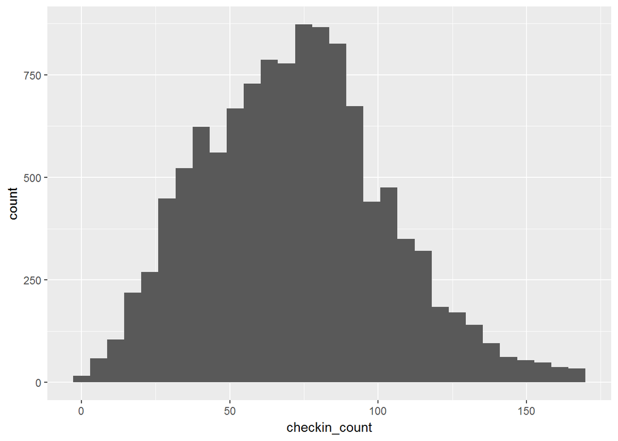

```r
#visualize data
require(ggplot2)
require(ggmap)
qplot(data=Restaurants_final,checkin_count)
```

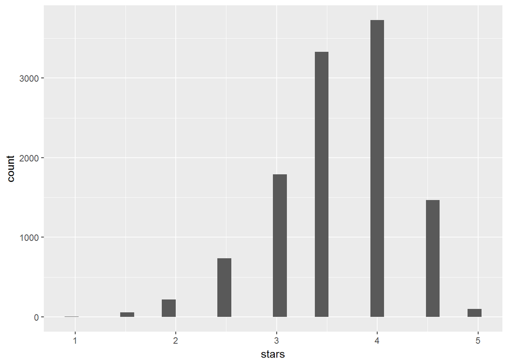

```r
qplot(data=Restaurants_final,stars)
```

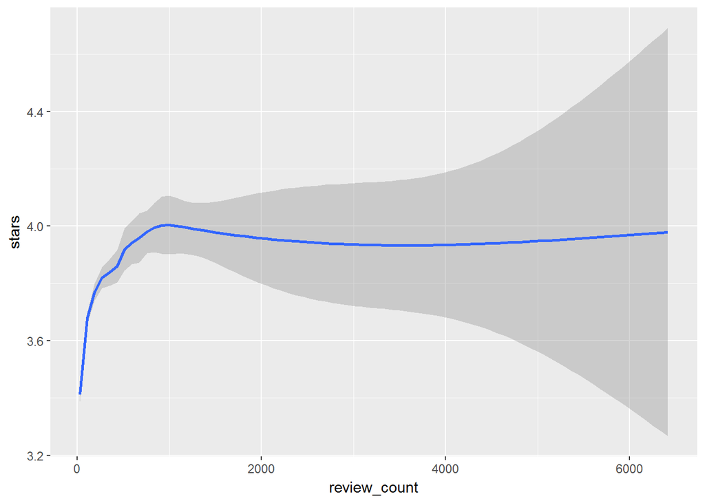

```r
qplot(data=Restaurants_final,review_count ,stars,geom="smooth")
```

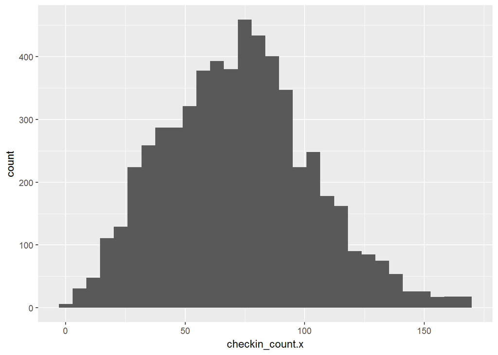

```r
qplot(data=RestaurantsTrainingSet,checkin_count.x)
```

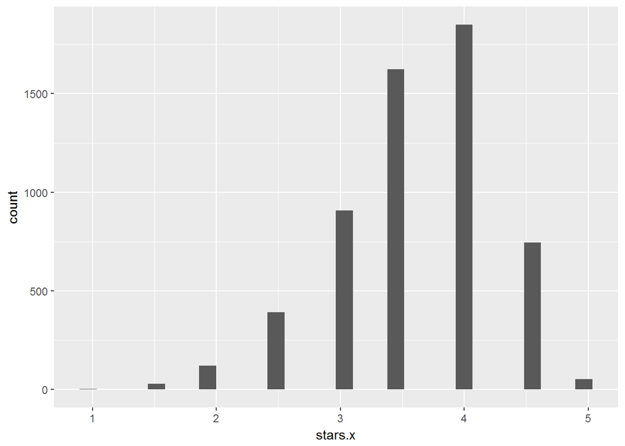

```r
qplot(data=RestaurantsTrainingSet,stars.x)
```

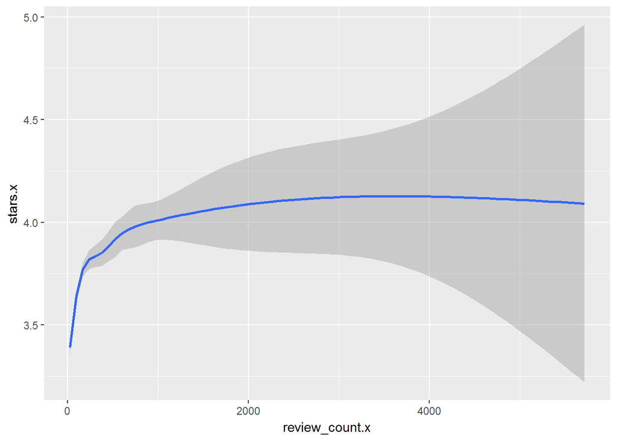

```r
qplot(data=RestaurantsTrainingSet,review_count.x ,stars.x,geom="smooth")
```

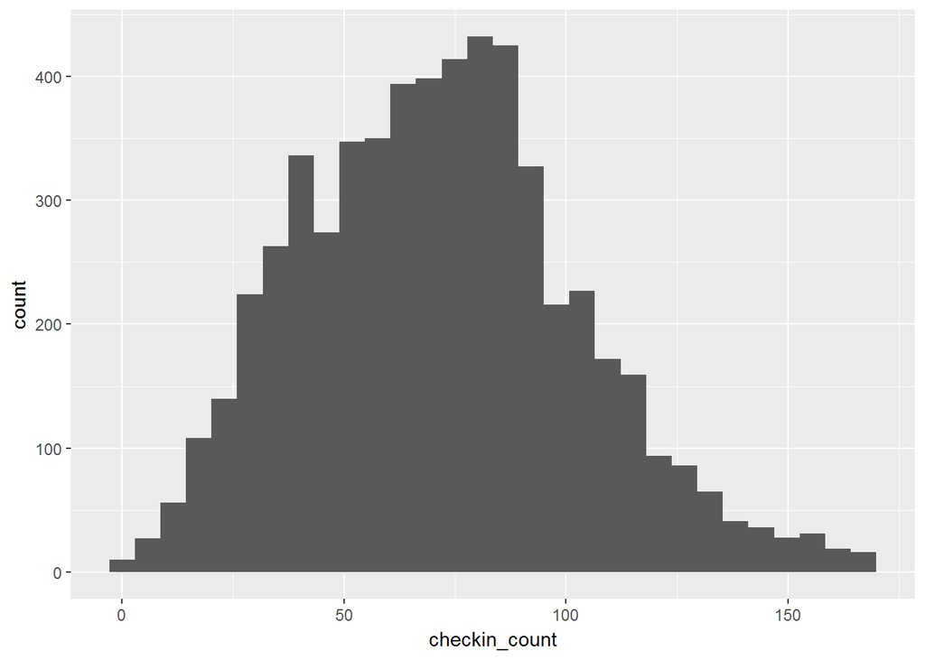

```r
qplot(data=RestaurantsTestSet,checkin_count)
```

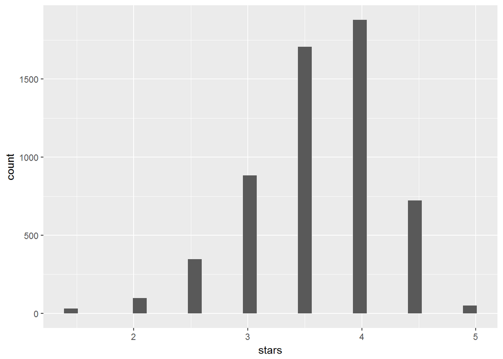

```r
qplot(data=RestaurantsTestSet,stars)
```

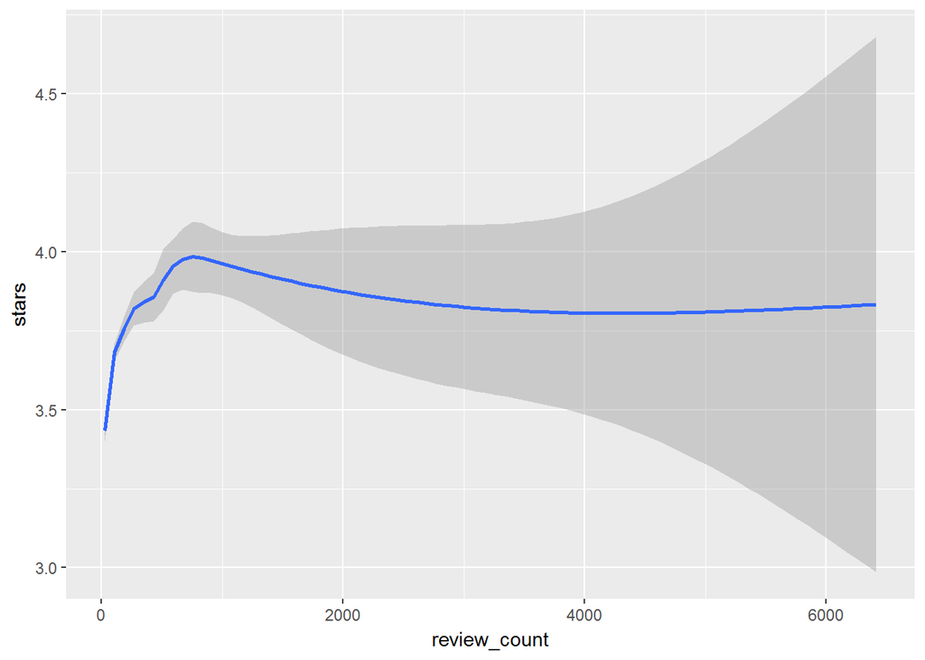

```r
qplot(data=RestaurantsTestSet,review_count ,stars,geom="smooth")
```

[figure not shown]

```r
map<-get_map(location='united states', zoom=4, maptype = "terrain",
             source='google',color='color')
ggmap(map) + geom_point(
        aes(x=longitude, y=latitude, show_guide = TRUE, colour=checkin_count),
        data=Restaurants_final, alpha=.5, na.rm = T)  +
        scale_color_gradient(low="red", high="blue")
```

[figure not shown]

```r
ggmap(map) + geom_point(
        aes(x=longitude, y=latitude, show_guide = TRUE, colour=stars),
        data=Restaurants_final, alpha=.5, na.rm = T)  +
        scale_color_gradient(low="red", high="blue")
```

1. Analyze the review text data using a Natural Language Processing package, to assess whether there are any interesting relationships between written reviews and number of stars. For example, are reviewers who give high ratings more likely to write long reviews, or use certain key words or phrases?
2. Analyze user data to understand the relationship between the frequency with which users write reviews on Yelp, and their propensity to give very high or lower ratings.
3. Analyze restaurant categories, tags, and hours, to assess whether they have any relationship with restaurant ratings and/or checkins.